# Test your knowledge of Clustering and Collaborative filtering

Term 5, 2024

# Question 1

## a)

There are a total of 11580 observations.

```r
stocks <- read.csv("StocksCluster.csv")
str(stocks)
```

```
## 'data.frame':    11580 obs. of  12 variables:
##  $ ReturnJan  : num  0.0807 -0.0107 0.0477 -0.074 -0.031 ...
##  $ ReturnFeb  : num  0.0663 0.1021 0.036 -0.0482 -0.2127 ...
##  $ ReturnMar  : num  0.0329 0.1455 0.0397 0.0182 0.0915 ...
##  $ ReturnApr  : num  0.1831 -0.0844 -0.1624 -0.0247 0.1893 ...
##  $ ReturnMay  : num  0.13033 -0.3273 -0.14743 -0.00604 -0.15385 ...
##  $ ReturnJune : num  -0.0176 -0.3593 0.0486 -0.0253 -0.1061 ...
##  $ ReturnJuly : num  -0.0205 -0.0253 -0.1354 -0.094 0.3553 ...
##  $ ReturnAug  : num  0.0247 0.2113 0.0334 0.0953 0.0568 ...
##  $ ReturnSep  : num  -0.0204 -0.58 0 0.0567 0.0336 ...
##  $ ReturnOct  : num  -0.1733 -0.2671 0.0917 -0.0963 0.0363 ...
##  $ ReturnNov  : num  -0.0254 -0.1512 -0.0596 -0.0405 -0.0853 ...
##  $ PositiveDec: int  0 0 0 1 1 1 1 0 0 0 ...
```

## b)

54.6114 percent of the observations had positive returns in December

```r
table(stocks$PositiveDec)/nrow(stocks)
```

```
##
##        0        1
## 0.453886 0.546114
```

## c)

Maximum correlation = 0.1916727856. By observing the correlation matrix, we can see it is between the returns of October and November.

```r
cor(stocks[,1:11])
```

```
##              ReturnJan   ReturnFeb    ReturnMar    ReturnApr    ReturnMay
## ReturnJan   1.00000000  0.06677458 -0.090496798 -0.037678006 -0.044411417
## ReturnFeb   0.06677458  1.00000000 -0.155983263 -0.191351924 -0.095520920
## ReturnMar  -0.09049680 -0.15598326  1.000000000  0.009726288 -0.003892789
## ReturnApr  -0.03767801 -0.19135192  0.009726288  1.000000000  0.063822504
## ReturnMay  -0.04441142 -0.09552092 -0.003892789  0.063822504  1.000000000
## ReturnJune  0.09223831  0.16999448 -0.085905486 -0.011027752 -0.021074539
## ReturnJuly -0.08142976 -0.06177851  0.003374160  0.080631932  0.090850264
## ReturnAug  -0.02279202  0.13155979 -0.022005400 -0.051756051 -0.033125658
## ReturnSep  -0.02643715  0.04350177  0.076518327 -0.028920972  0.021962862
## ReturnOct   0.14297723 -0.08732427 -0.011923758  0.048540025  0.017166728
## ReturnNov   0.06763233 -0.15465828  0.037323535  0.031761837  0.048046590
##             ReturnJune    ReturnJuly     ReturnAug     ReturnSep   ReturnOct
## ReturnJan   0.09223831 -0.0814297650 -0.0227920187 -0.0264371526  0.14297723
## ReturnFeb   0.16999448 -0.0617785094  0.1315597863  0.0435017706 -0.08732427
## ReturnMar  -0.08590549  0.0033741597 -0.0220053995  0.0765183267 -0.01192376
## ReturnApr  -0.01102775  0.0806319317 -0.0517560510 -0.0289209718  0.04854003
## ReturnMay  -0.02107454  0.0908502642 -0.0331256580  0.0219628623  0.01716673
## ReturnJune  1.00000000 -0.0291525996  0.0107105260  0.0447472692 -0.02263599
## ReturnJuly -0.02915260  1.0000000000  0.0007137558  0.0689478037 -0.05470891
## ReturnAug   0.01071053  0.0007137558  1.0000000000  0.0007407139 -0.07559456
## ReturnSep   0.04474727  0.0689478037  0.0007407139  1.0000000000 -0.05807924
## ReturnOct  -0.02263599 -0.0547089088 -0.0755945614 -0.0580792362  1.00000000
## ReturnNov  -0.06527054 -0.0483738369 -0.1164890345 -0.0197197998  0.19167279
##              ReturnNov
## ReturnJan   0.06763233
## ReturnFeb  -0.15465828
## ReturnMar   0.03732353
## ReturnApr   0.03176184
## ReturnMay   0.04804659
## ReturnJune -0.06527054
## ReturnJuly -0.04837384
## ReturnAug  -0.11648903
## ReturnSep  -0.01971980
## ReturnOct   0.19167279
## ReturnNov   1.00000000
```

```r
sort(cor(stocks[,1:11]))
```

```
##   [1] -0.1913519239 -0.1913519239 -0.1559832630 -0.1559832630 -0.1546582815
##   [6] -0.1546582815 -0.1164890345 -0.1164890345 -0.0955209197 -0.0955209197
##  [11] -0.0904967978 -0.0904967978 -0.0873242672 -0.0873242672 -0.0859054862
##  [16] -0.0859054862 -0.0814297650 -0.0814297650 -0.0755945614 -0.0755945614
##  [21] -0.0652705413 -0.0652705413 -0.0617785094 -0.0617785094 -0.0580792362
##  [26] -0.0580792362 -0.0547089088 -0.0547089088 -0.0517560510 -0.0517560510
##  [31] -0.0483738369 -0.0483738369 -0.0444114168 -0.0444114168 -0.0376780060
##  [36] -0.0376780060 -0.0331256580 -0.0331256580 -0.0291525996 -0.0291525996
##  [41] -0.0289209718 -0.0289209718 -0.0264371526 -0.0264371526 -0.0227920187
##  [46] -0.0227920187 -0.0226359936 -0.0226359936 -0.0220053995 -0.0220053995
##  [51] -0.0210745388 -0.0210745388 -0.0197197998 -0.0197197998 -0.0119237577
##  [56] -0.0119237577 -0.0110277522 -0.0110277522 -0.0038927894 -0.0038927894
##  [61]  0.0007137558  0.0007137558  0.0007407139  0.0007407139  0.0033741597
##  [66]  0.0033741597  0.0097262876  0.0097262876  0.0107105260  0.0107105260
##  [71]  0.0171667279  0.0171667279  0.0219628623  0.0219628623  0.0317618366
##  [76]  0.0317618366  0.0373235349  0.0373235349  0.0435017706  0.0435017706
##  [81]  0.0447472692  0.0447472692  0.0480465902  0.0480465902  0.0485400254
##  [86]  0.0485400254  0.0638225039  0.0638225039  0.0667745831  0.0667745831
##  [91]  0.0676323333  0.0676323333  0.0689478037  0.0689478037  0.0765183267
##  [96]  0.0765183267  0.0806319317  0.0806319317  0.0908502642  0.0908502642
## [101]  0.0922383068  0.0922383068  0.1315597863  0.1315597863  0.1429772286
## [106]  0.1429772286  0.1699944833  0.1699944833  0.1916727856  0.1916727856
## [111]  1.0000000000  1.0000000000  1.0000000000  1.0000000000  1.0000000000
## [116]  1.0000000000  1.0000000000  1.0000000000  1.0000000000  1.0000000000
## [121]  1.0000000000
```

## d)

Maximum mean return is in April and minimum mean return is in September.

```r
colMeans(stocks[,1:11])
```

```
##    ReturnJan    ReturnFeb    ReturnMar    ReturnApr    ReturnMay   ReturnJune
##  0.012631602 -0.007604784  0.019402336  0.026308147  0.024736591  0.005937902
##   ReturnJuly    ReturnAug    ReturnSep    ReturnOct    ReturnNov
##  0.003050863  0.016198265 -0.014720768  0.005650844  0.011387440
```

```r
which(colMeans(stocks[,1:11]) == max(colMeans(stocks[,1:11])))
```

```
## ReturnApr
##         4
```

```r
which(colMeans(stocks[,1:11]) == min(colMeans(stocks[,1:11])))
```

```
## ReturnSep
##         9
```

## e)

Accuracy = 0.5711818

```r
library(caTools)
set.seed(144)
spl <- sample.split(stocks$PositiveDec, SplitRatio = .7)
stocksTrain <- subset(stocks, spl == TRUE)
stocksTest <- subset(stocks, spl == FALSE)
stocksModel <- glm(PositiveDec ~ ., data = stocksTrain, family = "binomial")
stocksPredict <- predict(stocksModel, newdata = stocksTrain, type = "response")
table(stocksPredict >= 0.5, stocksTrain$PositiveDec)
```

```
##
##            0    1
##   FALSE  990  787
##   TRUE  2689 3640
```

```r
(990+3640)/(990+787+2689+3640)
```

```
## [1] 0.5711818
```

## f)

Accuracy on test set = 0.5670697 (close to what we see on the training set)

```r
stocksPredicttest <- predict(stocksModel, newdata = stocksTest, type = "response")
table(stocksPredicttest >= .5, stocksTest$PositiveDec)
```

```
##
##            0    1
##   FALSE  417  344
##   TRUE  1160 1553
```

```r
(417+1553)/(417+344+1160+1553)
```

```
## [1] 0.5670697
```

## g)

Baseline model predicts positive return (majority in training set). Accuracy of this on test set = 0.5460564.

```r
table(stocksTrain$PositiveDec)
```

```
##
##    0    1
## 3679 4427
```

```r
table(stocksTest$PositiveDec)
```

```
##
##    0    1
## 1577 1897
```

```r
1897/(1897+1577)
```

```
## [1] 0.5460564
```

## h)

We remove the dependent variable in the clustering phase since needing to know the dependent variable in assigning an observation to a cluster defeats the purpose of the methodology (option iii).

```r
limitedTrain <- stocksTrain
limitedTrain$PositiveDec <- NULL
limitedTest <- stocksTest
limitedTest$PositiveDec <- NULL
```

## i)

Mean of ReturnJan in training set = 0 (normalized) while in the test set it is -0.0004185886.

```r
#install.packages("caret")
library(caret)
preproc <- preProcess(limitedTrain)
normTrain <- predict(preproc, limitedTrain)
normTest <- predict(preproc, limitedTest)
colMeans(normTrain)
```

```
##     ReturnJan     ReturnFeb     ReturnMar     ReturnApr     ReturnMay
## -4.362549e-16 -7.001555e-17 -5.925572e-16  1.594619e-16 -7.883597e-17
##    ReturnJune    ReturnJuly     ReturnAug     ReturnSep     ReturnOct
## -5.710403e-16 -2.018836e-17 -3.629523e-18 -4.470134e-16  1.036920e-15
##     ReturnNov
## -2.527654e-17
```

```r
colMeans(normTest)
```

```
##     ReturnJan     ReturnFeb     ReturnMar     ReturnApr     ReturnMay
## -0.0004185886 -0.0038621679  0.0058299150 -0.0363806373  0.0265120925
##    ReturnJune    ReturnJuly     ReturnAug     ReturnSep     ReturnOct
##  0.0431544402  0.0060164183 -0.0497332436  0.0293887872  0.0296723768
##     ReturnNov
##  0.0171281833
```

## j)

The mean is 0 in training set since the distribution in training and test set are not identical and normalization is done on the training set.

## k)

Cluster 2 has the largest number of observations (4731).

```r
set.seed(144)
km <- kmeans(normTrain, centers = 3)
table(km$cluster)
```

```
##
##    1    2    3
## 2479 4731  896
```

## l)

Cluster 2 has the 2029 observations in the test set.

```r
#install.packages("flexclust")
library(flexclust)
?as.kcca
km.kcca <- as.kcca(km, normTrain)
clusterTrain <- predict(km.kcca)
clusterTest <- predict(km.kcca, newdata = normTest)
table(clusterTest)
```

```
## clusterTest
##    1    2    3
## 1058 2029  387
```

## m)

stocksTrain1 (from cluster 1) has the highest average value of the dependent varibale in the training set.

```r
stocksTrain1 <- subset(stocksTrain, clusterTrain == 1)
stocksTrain2 <- subset(stocksTrain, clusterTrain == 2)
stocksTrain3 <- subset(stocksTrain, clusterTrain == 3)
stocksTest1 <- subset(stocksTest, clusterTest == 1)
stocksTest2 <- subset(stocksTest, clusterTest == 2)
stocksTest3 <- subset(stocksTest, clusterTest == 3)
mean(stocksTrain1$PositiveDec)
```

```
## [1] 0.6103267
```

```r
mean(stocksTrain2$PositiveDec)
```

```
## [1] 0.5250476
```

```r
mean(stocksTrain3$PositiveDec)
```

```
## [1] 0.4799107
```

## n)

ReturnFeb, ReturnMar, ReturnJuly, ReturnSep have positive coefficient in one of the three models (at least) and negative coefficient in one of the three models (at least).

```r
StocksModel1 <- glm(PositiveDec ~ ., data = stocksTrain1, family = "binomial")
StocksModel2 <- glm(PositiveDec ~ ., data = stocksTrain2, family = "binomial")
StocksModel3 <- glm(PositiveDec ~ ., data = stocksTrain3, family = "binomial")
summary(StocksModel1)
```

```
##
## Call:
## glm(formula = PositiveDec ~ ., family = "binomial", data = stocksTrain1)
##
## Coefficients:
##             Estimate Std. Error z value Pr(>|z|)
## (Intercept)  0.20739    0.08020   2.586  0.00971 **
## ReturnJan    0.12448    0.31474   0.396  0.69246
## ReturnFeb   -0.46307    0.32713  -1.416  0.15692
## ReturnMar    0.55465    0.24804   2.236  0.02534 *
## ReturnApr    1.08354    0.25005   4.333 1.47e-05 ***
## ReturnMay    0.30487    0.24993   1.220  0.22253
## ReturnJune   0.00172    0.33525   0.005  0.99591
## ReturnJuly  -0.02763    0.30216  -0.091  0.92714
## ReturnAug    0.40299    0.34570   1.166  0.24373
## ReturnSep    0.70779    0.32611   2.170  0.02998 *
## ReturnOct   -1.33254    0.29055  -4.586 4.51e-06 ***
## ReturnNov   -0.78944    0.30583  -2.581  0.00984 **
## ---
## Signif. codes:  0 '***' 0.001 '**' 0.01 '*' 0.05 '.' 0.1 ' ' 1
##
## (Dispersion parameter for binomial family taken to be 1)
##
##     Null deviance: 3314.9  on 2478  degrees of freedom
## Residual deviance: 3244.0  on 2467  degrees of freedom
## AIC: 3268
##
## Number of Fisher Scoring iterations: 4
```

```r
summary(StocksModel2)
```

```
##
## Call:
## glm(formula = PositiveDec ~ ., family = "binomial", data = stocksTrain2)
##
## Coefficients:
##               Estimate Std. Error z value Pr(>|z|)
## (Intercept)  0.1165255  0.0335061   3.478 0.000506 ***
## ReturnJan    0.4489316  0.2414090   1.860 0.062938 .
## ReturnFeb   -0.1385458  0.1514734  -0.915 0.360373
## ReturnMar    0.4657754  0.2442129   1.907 0.056488 .
## ReturnApr    0.7839726  0.2558668   3.064 0.002184 **
## ReturnMay    0.7709831  0.2625217   2.937 0.003316 **
## ReturnJune   0.5764584  0.2191809   2.630 0.008537 **
## ReturnJuly   0.8654737  0.2869778   3.016 0.002563 **
## ReturnAug    0.0177313  0.2317020   0.077 0.939001
## ReturnSep    1.0464947  0.2684133   3.899 9.67e-05 ***
## ReturnOct   -0.0001062  0.2426989   0.000 0.999651
## ReturnNov   -0.3716212  0.2603210  -1.428 0.153421
## ---
## Signif. codes:  0 '***' 0.001 '**' 0.01 '*' 0.05 '.' 0.1 ' ' 1
##
## (Dispersion parameter for binomial family taken to be 1)
##
##     Null deviance: 6546.7  on 4730  degrees of freedom
## Residual deviance: 6481.4  on 4719  degrees of freedom
## AIC: 6505.4
##
## Number of Fisher Scoring iterations: 4
```

```r
summary(StocksModel3)
```

```
##
## Call:
## glm(formula = PositiveDec ~ ., family = "binomial", data = stocksTrain3)
##
## Coefficients:
##             Estimate Std. Error z value Pr(>|z|)
## (Intercept)   0.4504     0.1700   2.649 0.008071 **
## ReturnJan     0.3816     0.2742   1.392 0.163927
## ReturnFeb     0.3943     0.4612   0.855 0.392490
## ReturnMar    -1.7220     0.4372  -3.938 8.20e-05 ***
## ReturnApr     0.5214     0.3275   1.592 0.111316
## ReturnMay     1.1301     0.4274   2.644 0.008194 **
## ReturnJune    1.5889     0.4423   3.592 0.000328 ***
## ReturnJuly    1.3800     0.4602   2.999 0.002709 **
## ReturnAug     0.4146     0.4824   0.860 0.390054
## ReturnSep    -0.0148     0.4754  -0.031 0.975167
## ReturnOct    -0.6820     0.3044  -2.241 0.025039 *
## ReturnNov    -1.7175     0.4133  -4.156 3.24e-05 ***
## ---
## Signif. codes:  0 '***' 0.001 '**' 0.01 '*' 0.05 '.' 0.1 ' ' 1
##
## (Dispersion parameter for binomial family taken to be 1)
##
##     Null deviance: 1240.7  on 895  degrees of freedom
## Residual deviance: 1131.5  on 884  degrees of freedom
## AIC: 1155.5
##
## Number of Fisher Scoring iterations: 4
```

## o)

```r
PredictTest1 <- predict(StocksModel1, newdata = stocksTest1, type = "response")
PredictTest2 <- predict(StocksModel2, newdata = stocksTest2, type = "response")
PredictTest3 <- predict(StocksModel3, newdata = stocksTest3, type = "response")
table1 <- table(PredictTest1 >= 0.5, stocksTest1$PositiveDec )
table1
```

```
##
##           0   1
##   FALSE  43  26
##   TRUE  350 639
```

```r
(43+639)/(43+639+26+350)
```

```
## [1] 0.6446125
```

```r
table2 <- table(PredictTest2 >= 0.5, stocksTest2$PositiveDec )
table2
```

```
##
##           0   1
##   FALSE 277 221
##   TRUE  719 812
```

```r
(227+812)/(227+812+221+719)
```

```
## [1] 0.5250126
```

```r
table3 <- table(PredictTest3 >= 0.5, stocksTest3$PositiveDec )
table3
```

```
##
##           0   1
##   FALSE 119  76
##   TRUE   69 123
```

```r
(119+123)/(119+123+76+69)
```

```
## [1] 0.625323
```

## p)

Overall accuracy = 0.5794473

```r
AllPredictions <- c(PredictTest1, PredictTest2, PredictTest3)
AllOutcomes <- c(stocksTest1$PositiveDec, stocksTest2$PositiveDec, stocksTest3$PositiveDec)
table4 <- table(AllPredictions >= 0.5, AllOutcomes)
table4
```

```
##        AllOutcomes
##            0    1
##   FALSE  439  323
##   TRUE  1138 1574
```

```r
(439+1574)/(439+1574+323+1138)
```

```
## [1] 0.5794473
```

# Question 2

## a)

There are 329 bike stations in the dataset.

```r
citi <- read.csv("citibike.csv")
str(citi)
```

```
## 'data.frame':    667738 obs. of  7 variables:
##  $ tripduration: int  861 757 773 228 456 632 424 1129 1275 440 ...
##  $ startstation: chr  "E 14 St & Avenue B" "University Pl & E 14 St" "Broadway & W 49 St" "1 Ave & E 15 St" ...
##  $ endstation  : chr  "E 51 St & 1 Ave" "Suffolk St & Stanton St" "9 Ave & W 45 St" "E 20 St & FDR Drive" ...
##  $ gender      : int  1 1 1 1 1 1 1 1 1 1 ...
##  $ age         : int  25 27 24 26 37 46 41 44 30 23 ...
##  $ day         : chr  "Mon" "Mon" "Mon" "Mon" ...
##  $ starttime   : int  0 0 0 0 0 0 0 0 0 0 ...
```

```r
length(unique(citi$startstation))
```

```
## [1] 329
```

```r
length(unique(citi$endstation))
```

```
## [1] 329
```

```r
nlevels(as.factor(citi$startstation))
```

```
## [1] 329
```

```r
nlevels(as.factor(citi$endstation))
```

```
## [1] 329
```

## b)

Average duration of trips taken by bikers is maximum on Sat with 894.26614 seconds.

```r
tapply(citi$tripduration,citi$day,mean)
```

```
##      Fri      Mon      Sat      Sun      Thu      Tue      Wed
## 832.3580 853.6248 894.2661 887.5528 865.7822 857.4895 843.5679
```

## c)

The maximum number of 65684 bike trips start at 18 (6 pm) and minimum number of 1151 bike trips start at 4 (4 am).

```r
max(table(citi$starttime))
```

```
## [1] 65684
```

```r
which.max(table(citi$starttime))
```

```
## 18
## 19
```

```r
min(table(citi$starttime))
```

```
## [1] 1151
```

```r
which.min(table(citi$starttime))
```

```
## 4
## 5
```

## d)

23.49904 percent of the bikes were rented by females.

```r
table(citi$gender)
```

```
##
##      1      2
## 510826 156912
```

```r
156912/(156912+510826)
```

```
## [1] 0.2349904
```

## e)

```r
citi$Mon <- as.integer(citi$day == "Mon")
citi$Tue <- as.integer(citi$day == "Tue")
citi$Wed <- as.integer(citi$day == "Wed")
citi$Thu <- as.integer(citi$day == "Thu")
citi$Fri <- as.integer(citi$day == "Fri")
citi$Sat <- as.integer(citi$day == "Sat")
citi$Sun <- as.integer(citi$day == "Sun")
```

## f)

The variable tripduration is in seconds and the numbers can be very large compared to other numbers and the others are categorical variables. You expect tripduration to dominate.

```r
summary(citi)
```

```
##   tripduration      startstation        endstation            gender
##  Min.   :    60.0   Length:667738      Length:667738      Min.   :1.000
##  1st Qu.:   410.0   Class :character   Class :character   1st Qu.:1.000
##  Median :   653.0   Mode  :character   Mode  :character   Median :1.000
##  Mean   :   859.1                                         Mean   :1.235
##  3rd Qu.:  1055.0                                         3rd Qu.:1.000
##  Max.   :730955.0                                         Max.   :2.000
##       age            day              starttime          Mon
##  Min.   :16.00   Length:667738      Min.   : 0.00   Min.   :0.0000
##  1st Qu.:29.00   Class :character   1st Qu.:10.00   1st Qu.:0.0000
##  Median :35.00   Mode  :character   Median :15.00   Median :0.0000
##  Mean   :37.47                      Mean   :14.25   Mean   :0.1605
##  3rd Qu.:44.00                      3rd Qu.:18.00   3rd Qu.:0.0000
##  Max.   :75.00                      Max.   :23.00   Max.   :1.0000
##       Tue              Wed              Thu              Fri
##  Min.   :0.0000   Min.   :0.0000   Min.   :0.0000   Min.   :0.0000
##  1st Qu.:0.0000   1st Qu.:0.0000   1st Qu.:0.0000   1st Qu.:0.0000
##  Median :0.0000   Median :0.0000   Median :0.0000   Median :0.0000
##  Mean   :0.1908   Mean   :0.1925   Mean   :0.1271   Mean   :0.1223
##  3rd Qu.:0.0000   3rd Qu.:0.0000   3rd Qu.:0.0000   3rd Qu.:0.0000
##  Max.   :1.0000   Max.   :1.0000   Max.   :1.0000   Max.   :1.0000
##       Sat              Sun
##  Min.   :0.0000   Min.   :0.0000
##  1st Qu.:0.0000   1st Qu.:0.0000
##  Median :0.0000   Median :0.0000
##  Mean   :0.1031   Mean   :0.1036
##  3rd Qu.:0.0000   3rd Qu.:0.0000
##  Max.   :1.0000   Max.   :1.0000
```

## g)

The maximum value pf trip duration after scaling is 402.9514.

```r
citi1 <- citi
citi1$tripduration <- scale(citi1$tripduration)
citi1$gender <- scale(citi1$gender)
citi1$age <- scale(citi1$age)
citi1$starttime <- scale(citi1$starttime)
citi1$Mon <- scale(citi1$Mon)
citi1$Tue <- scale(citi1$Tue)
citi1$Wed <- scale(citi1$Wed)
citi1$Thu <- scale(citi1$Thu)
citi1$Fri <- scale(citi1$Fri)
citi1$Sat <- scale(citi1$Sat)
citi1$Sun <- scale(citi1$Sun)
max(citi1$tripduration)
```

```
## [1] 402.9514
```

## h)

The data has 667738 observations. Since there are so many bike rides and we need to compute distance between observations (each pair) this will be computationally intensive for hierarchical clustering (third option is best answer).

## i)

Smallest cluster size is 415 and largest cluster size is 148501.

```r
set.seed(100)
cluster1 <- kmeans(citi1[,c("tripduration","gender","age","starttime","Mon","Tue","Wed","Thu","Fri","Sat","Sun")],centers=10)
min(cluster1$size)
```

```
## [1] 415
```

```r
max(cluster1$size)
```

```
## [1] 148501
```

## j)

Cluster 2 seems to fit the description.

```r
cluster1$centers
```

```
##    tripduration      gender          age    starttime        Mon         Tue
## 1   0.044850929  1.80429727 -0.095260498  0.049541395 -0.4372836  2.05949316
## 2  -0.013956803 -0.55423157 -0.058620191  0.014803368 -0.4372836 -0.48555563
## 3  -0.038902493 -0.55423157  0.066697150 -0.011107027  1.0876662 -0.48555563
## 4  25.929730536  0.16753509 -0.001699841  0.222440514  0.2125681 -0.01334176
## 5  -0.027670945 -0.03075913  0.006205345 -0.090524395 -0.4372836 -0.48555563
## 6  -0.038930509 -0.55423157  0.078267268  0.004043672 -0.4372836 -0.48555563
## 7  -0.041770529 -0.55423157  0.073173182  0.004626465 -0.4372836  2.05949316
## 8   0.048453978  1.80429727 -0.102888809  0.047410383  0.4627441 -0.48555563
## 9   0.001185646  0.08493623 -0.126900987  0.026110387 -0.4372836 -0.48555563
## 10  0.057722791  1.80429727 -0.187086384  0.036513989 -0.4372836 -0.48555563
##           Wed         Thu         Fri         Sat           Sun
## 1  -0.4882786 -0.38164199 -0.37336420 -0.33910571 -0.3398930409
## 2  -0.4882786 -0.38164199 -0.37336420  2.94892855 -0.3398930409
## 3  -0.4882786  0.93980950 -0.37336420 -0.33910571 -0.3398930409
## 4  -0.1338096  0.05236691 -0.07186994 -0.04595567  0.0001686408
## 5  -0.4882786 -0.38164199  2.67834598 -0.33910571 -0.3398930409
## 6   2.0480080 -0.38164199 -0.37336420 -0.33910571 -0.3398930409
## 7  -0.4882786 -0.38164199 -0.37336420 -0.33910571 -0.3398930409
## 8   0.5293629  0.42399383 -0.37336420 -0.33910571 -0.3398930409
## 9  -0.4882786 -0.38164199 -0.37336420 -0.33910571  2.9420976077
## 10 -0.4882786 -0.38164199 -0.37336420  2.94892855 -0.3398930409
```

## k)

Cluster 1 seems to fit the description.

## l)

You would get different results from the first k-means clustering.

## m)

You will get identical results as the first k-means clustering.

## n)

Here we are looking for:

- longer trips - tripduration (+),
- old - age (+),
- female - gender(+),
- weekdays - weekday (+).

We create `cluster2` using k-means with 10 clusters below after consolidating the weekday variable and then normalizing it. Cluster 8 best fits the description (in this particular clustering, it may be different in your version).

```r
citi1$weekday <- 1-as.integer(citi$Sat==1|citi$Sun==1)
citi1$weekday <- scale(citi1$weekday)
set.seed(100)
cluster2 <- kmeans(citi1[,c("tripduration","gender","age","starttime", "weekday")],centers=10)
cluster2$centers
```

```
##    tripduration     gender        age    starttime    weekday
## 1   0.068125857  1.8042973 -0.6145049  0.798622842  0.5104419
## 2  -0.018539870 -0.5542316 -0.5576231  0.438721207 -1.9590838
## 3  -0.032074204 -0.5542316  1.1733024 -1.015304757  0.5104419
## 4   0.245447412  1.7962770 -0.2492597  0.039847558 -1.9504195
## 5  -0.023480516 -0.5542316 -0.5987229  0.781944114  0.5104419
## 6   0.004664012 -0.5542316  1.1246967  0.649386189  0.5100614
## 7  -0.077872915 -0.5542316 -0.5547152 -1.078754475  0.5100357
## 8   0.076219228  1.8042973  1.3469579  0.008629251  0.4707794
## 9   0.004461763  1.8042973 -0.5170873 -1.062853104  0.5104419
## 10 -0.014680584 -0.5493999  0.7230601 -0.671832851 -1.9590838
```

## o)

Here we are looking for in `cluster2` above:

- short trips - tripduration (-),
- young - age (-),
- male - gender(-),
- early - starttime (-),
- weekdays - weekday (+).

Cluster 7 fits this description the best (in this particular clustering, it may be different for a different version of R).

# Question 3

*The solution has been modified*

Things to be noted for this solution:

- We need to keep track of the correlation scores, unlike in the class notes where they are discarded/overwritten as soon as the order is known.
- Whenever a relevant neighbor of user `u`, let’s say user `v`, has a missing entry (user `v` did not rate a certain movie), we should not consider the correlation between `u` and `v` when computing the sum of weights (in the denominator):

$$p_{ui} = \frac{\sum_{v\in N_u} S_{u,v}
r_{v,i}}{\sum_{v\in N_u} S_{u,v}}$$

- Correlation scores are between -1 and 1. This means that the weighted average can be smaller than 0 or greater than 5. Let us simply project these values onto the feasible output set, i.e. negative scores will be changed to 0, and scores greater than 5 will be changed to 5.
- Use apply to calculate the column means, with the user-defined function `w.avg` that calculates the proper weighted average, and projects the predicted scores onto the feasibleoutput set:

```r
w.avg <- function(x,y){
# If y'all want to use weighted.mean instead, take note to include
# the separate argument "na.rm=TRUE" in the apply() function call
# z <- weighted.mean(x,y,na.rm=TRUE)
z <- sum(x*y, na.rm=TRUE)/sum(y[which(!is.na(x))])
if (!is.na(z)){
if(z>5){z <- 5}
if(z<0){z <- 0}
}
return(z)
}
```

Now we do the computations below.

```r
ratings <- read.csv("ratings.csv")
Data <- matrix(nrow=length(unique(ratings$userId)),ncol=length(unique(ratings$movieId)))
rownames(Data) <- unique(ratings$userId)
colnames(Data) <- unique(ratings$movieId)
for(i in 1:nrow(ratings)){
  Data[as.character(ratings$userId[i]),as.character(ratings$movieId[i])] <- ratings$rating[i]
}
Datanorm <- Data - rowMeans(Data,na.rm=TRUE)


set.seed(1)
spl1 <- sample(1:nrow(Data), 0.98*nrow(Data)) # spl1 has 98% of the rows
spl1c <- setdiff(1:nrow(Data),spl1)           # spl1c has the remaining ones
spl2 <- sample(1:ncol(Data), 0.8*ncol(Data))  # spl2 has 80% of the columns
spl2c <- setdiff(1:ncol(Data),spl2)           # spl2c has the rest

Base1    <- matrix(nrow=length(spl1c), ncol=length(spl2c))
Base2    <- matrix(nrow=length(spl1c), ncol=length(spl2c))
UserPred <- matrix(nrow=length(spl1c), ncol=length(spl2c))
for(i in 1:length(spl1c)){
  Base1[i,] <- colMeans(Datanorm[spl1,spl2c], na.rm=TRUE)
}
for(j in 1:length(spl2c)){
  Base2[,j] <- rowMeans(Datanorm[spl1c,spl2], na.rm=TRUE)
}
RMSEBase1    <- sqrt(mean((Datanorm[spl1c,spl2c] - Base1)^2, na.rm=TRUE))
RMSEBase2    <- sqrt(mean((Datanorm[spl1c,spl2c] - Base2)^2, na.rm= TRUE))


Cor <- matrix(nrow=length(spl1c),ncol=length(spl1))
Order <- matrix(nrow=length(spl1c), ncol=length(spl1))

suppressWarnings(
for(i in 1:length(spl1c))
{for(j in 1:length(spl1))
{Cor[i,j] <- cor(Data[spl1c[i],spl2],Data[spl1[j],spl2],use = "pairwise.complete.obs")}
V <- order(Cor[i,], decreasing=TRUE, na.last=NA)
Order[i,] <- c(V, rep(NA, times=length(spl1)- length(V)))}
)
numk <- c(10,50,100,150,200,250,300)
RMSE <- rep(NA, times=length(numk))
for(ind in 1:length(numk)){
k <- numk[ind]
UserPred <- matrix(nrow=length(spl1c), ncol=length(spl2c))
for(i in 1:length(spl1c)){
w <- Cor[i,Order[i,1:k]]
D <- Data[spl1[Order[i,1:k]],spl2c]
UserPred[i,] <- apply(D,2,w.avg,y=w)
}
RMSE[ind] <- sqrt(mean((Data[spl1c,spl2c] - UserPred)^2,na.rm=TRUE))
}

RMSEBase1
```

```
## [1] 0.9169228
```

```r
RMSEBase2
```

```
## [1] 0.957262
```

```r
RMSE
```

```
## [1] 0.9554472 1.2907740 1.0929435 1.0238689 1.0965654 1.0967457 1.0684292
```

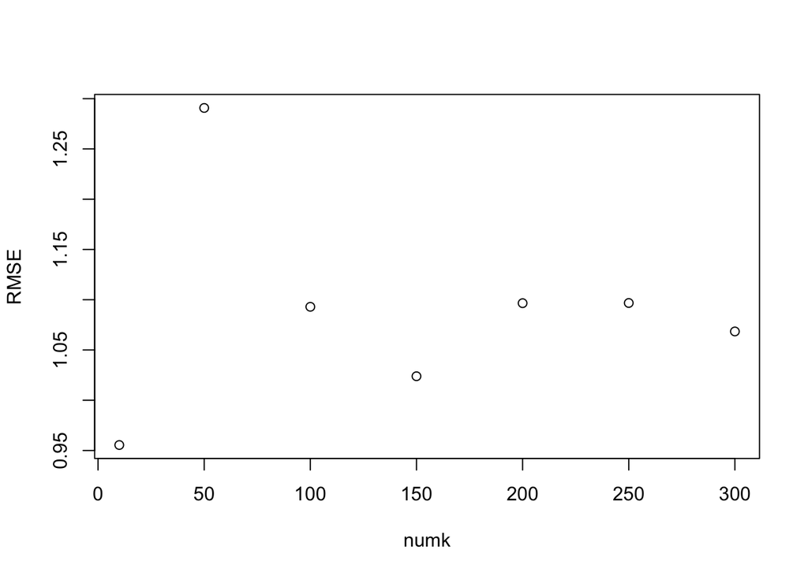

```r
plot(numk,RMSE)
```